# xmsPANDA R code Instruction

Chunyu Ma

Clinical Biomarker Laboratory, Emory University  
chunyu.ma@emory.edu

March 12, 2019

# Installation Prerequisites

Before starting to run the codes below, there are a few important R packages you need to pre-install on your computer.

1. [xmsPANDA ( >= version 1.0.7.5 )](https://github.com/kuppal2/xmsPANDA)
2. [lsmeans](https://cran.r-project.org/web/packages/lsmeans/index.html)
3. [car](https://cran.r-project.org/web/packages/car/index.html)
4. [devtools](https://cran.r-project.org/web/packages/devtools/index.html)

You can use the command below to install these packages. However, installing xmsPANDA is a tough process as you may need to install different dependencies. So please make sure you have a little bit R experience if you want to install xmsPANDA on your computer. Otherwise I will suggest to use our xmsPANDA shiny app instead.

Using the following commands to install the packages above:

```r
install.packages('devtools')
library(devtools)
install_github('kuppal2/xmsPANDA')
install.packages('lsmeans')
install.packages('car')
```

# Run the main function

The `diffexp` function is a wrapper function for xmsPANDA to complete the entire analysis workflow. Please run your analysis by using the following code with your preferred parameters.

```r
#load xmsPANDA, lsmeans and car packages
library(xmsPANDA)
library(lsmeans)
library(car)

#update the lattest source. Before xmsPANDA is officially released, the source code is always modified. You can always find the lattest source in https://github.com/kuppal2/xmsPANDA.
source("xmsPANDA_v1.0.6.72.R")

# set up the location of your input files and output files
feature_table_file<-"/home/cma/Destop/AMD_vs_control_feature_table.txt"
class_labels_file<-"/home/cma/Destop/AMD_vs_control_classlabel.txt"
outloc<-"/home/cma/Destop/xmspandaouttest"

#start: see manual for additional arguments and description
demetabs_res<-diffexp(

  #1) arguments for input files
  feature_table_file=feature_table_file,
  parentoutput_dir=outloc,
  class_labels_file=class_labels_file,
  input.intensity.scale="raw",

  ##2) data preprocessing order: 1) summarization, 2) filtering by missing values, 3) imputation; 4) transformation and normalization: halffeaturemin
  num_replicates = 1,
  summarize.replicates =TRUE, summary.method="median",summary.na.replacement="halffeaturemin",
  rep.max.missing.thresh=0.3,
  all.missing.thresh=0.1, group.missing.thresh=0.8, missing.val=0,
  log2transform = TRUE, medcenter=FALSE, znormtransform = FALSE,
  quantile_norm = TRUE, lowess_norm = FALSE, madscaling = FALSE,
  TIC_norm=FALSE,
  rsd.filt.list = c(1),

  ##3) arguments for feature seletion:
  #c("limma","pls","pamr","spls","pls","MARS","RF","rfesvm","logitreg","ttest","wilcox","o1pls","lmreg")
  #"rfesvm","pamr","MARS","RF","logitreg","ttest","wilcox","o1pls","lmreg","lm1wayanova"
  #c("limma","pls","spls","pls","MARS","RF","rfesvm","logitreg","ttest","wilcox","o1pls","lmreg","lm1wayanova")
  pairedanalysis = FALSE, featselmethod=c("pls"),
  pvalue.thresh=0.05,
  fdrthresh = 1, fdrmethod="none",
  kfold=5,networktype="complete",
  samplermindex=NA,numtrees=5000,analysismode="classification",pls_vip_thresh = 2, num_nodes = 3,
  max_varsel = 100, pls_ncomp = 5,pred.eval.method="BER",rocfeatlist=seq(2,10,1),
  rocfeatincrement=TRUE,
  rocclassifier="svm",foldchangethresh=0,
  optselect=TRUE,max_comp_sel=5,saveRda=FALSE,pls.permut.count=NA,
  pca.ellipse=TRUE,ellipse.conf.level=0.95,svm.acc.tolerance=5,pamr.threshold.select.max=FALSE,
  aggregation.method="none",mars.gcv.thresh=50,

  #4) arguments for WGCNA and global clustering analysis (HCA and EM clustering)
  wgcnarsdthresh=30,WGCNAmodules=FALSE,globalclustering=FALSE,

  #5) arguments for correlation and network analysis using the selected features
  cor.method="spearman", abs.cor.thresh = 0.4, cor.fdrthresh=0.2,
  globalcor=FALSE,target.metab.file=NA,
  target.mzmatch.diff=10,target.rtmatch.diff=NA,max.cor.num=NA,

  #6) arguments for graphical options: see manual for additional arguments
  output.device.type="png",pca.cex.val=4,legendlocation="bottomleft",
  net_node_colors=c("green","red"),net_legend=FALSE,
  heatmap.col.opt="RdBu",sample.col.opt="journal",
  boxplot.col.opt=c("journal"),barplot.col.opt="brewer.RdBu",
  plot.barplot=FALSE,plot.lineplot=FALSE,plot.sampleplot=FALSE,
  aggregation.max.iter=100
)
sink(file=NULL)
#end

####################################################################
#Options for featselmethod:
#"limma": for one-way ANOVA using LIMMA (mode=classification)
#"limma2way": for two-way ANOVA using LIMMA (mode=classification)
#"limma1wayrepeat": for one-way ANOVA repeated measures using LIMMA (mode=classification)
#"limma2wayrepeat": for two-way ANOVA repeated measures using LIMMA (mode=classification)
#"lm1wayanova": for one-way ANOVA using linear model (mode=classification)
#"lm2wayanova": for two-way ANOVA using linear model (mode=classification)
#"lm1wayanovarepeat": for one-way ANOVA repeated measures using linear model (mode=classification)
#"lm2wayanovarepeat": for two-way ANOVA repeated measures using linear model (mode=classification)
#"lmreg": variable selection based on p-values calculated using a linear regression model;
#allows adjustment for covariates (mode= regression or classification)
#"logitreg": variable selection based on p-values calculated using a logistic regression model;
# allows adjustment for covariates (mode= classification)
#"rfesvm": uses recursive feature elimination SVM algorithm for variable selection;
#(mode=classification)
#"wilcox": uses Wilcoxon tests for variable selection;
#(mode=classification)
#"RF": for random forest based feature selection (mode= regression or classification)
#"RFconditional": for conditional random forest based feature selection (mode= regression or classification)
#"pamr": for prediction analysis for microarrays algorithm based on the nearest shrunked centroid method (mode=classification)
#"MARS": for multiple adaptive regression splines (MARS) based feature selection
#(mode= regression or classification)
#"pls": for partial least squares (PLS) based feature selection
#(mode= regression or classification)
#"spls": for sparse partial least squares (PLS) based feature selection
#(mode= regression or classification)
#"o1pls": for orthogonal partial least squares (OPLS) based feature selection
#(mode= regression or classification)
####################################################################
```

For the usage of each argument, please refer to the lattest manual in [here](https://github.com/kuppal2/xmsPANDA/blob/master/examples_and_manual/xmsPANDA-manual.pdf).

Here I would like to introuduce a few important arguments:

- `input.intensity.scale`: This argument is used to let the program know your input scale. There are two options: ‘raw’ and ‘log2’.
- `num_replicates`: This argument is used to let the program know the number of technical replicates for each sample.
- `summarize.replicates`: This argument is used to control if the technical replicates per sample need to be averaged or median summarized.
- `summary.method`: This argument is used to control the method for summarizing the replicates. Options: “mean” or "median.
- `summary.na.replacement`: This argument is used to control if the missing values be represented. For its options, please refer to the manual.
- `all.missing.thresh`: This argument is used to control what propotion of total number of samples should have an intensity.
- `group.missing.thresh`: This argument is used to control what propotion of samples in either of the two groups should have an intensity.
- `missing.val`: This argument is used to control how the missing values are represented in the input data.
- `pairedanalysis`: This argument is used to let the program know if your study is a paired-study design.
- `featselmethod`: This argument is used to choose the methods that you want to use.
- `pvalue.thresh`: This argument is used to control the threshold of the p-value.
- `fdrthresh`: This argument is used to control the threshold of the FDR.
- `analysismode`: “classification” for group-wise comparison (case vs control) or “regression” for continuous response variables.
- `pls_vip_thresh`: This argument is used to control the threshold of the VIP for PLS-related methods.

# Run the additional functions

To indicate the functions below, I would like to use the high-resolution metabolomics dataset from a published study ( [Chandler, 2016](https://www.ncbi.nlm.nih.gov/pubmed/27558316) ) as an example. This study examined H1N1 influenza virus infection-altered metabolic response in mouse lung. The dataset includes data for 4,567 metabolic features across 10 mice (Ncontrol=5, NH1N1=5). You can download the dataset from [here](https://github.com/joneslabemory/March182019-metabolomics-analysis-workshop/tree/master/example%20data/xmsPANDA). In addition, I’m not going to explain the meaning of each argument. To know more about the details of each argument, please refer to the lattest xmsPANDA manual in [here](https://github.com/kuppal2/xmsPANDA/blob/master/examples_and_manual/xmsPANDA-manual.pdf).

## data preprocessing

The `data_preprocess` function is to pre-process your data, including summarization, filtering, transformation and normalization.

```r
#set up your working directory
setwd("~/Desktop/xmsPANDA_current20190302/myfiles")
#read the feature table
feat=read.table('expanda_feattable.txt',sep='\t',header=TRUE,stringsAsFactors = FALSE,check.names = FALSE)
#read the classlabel file
clabel=read.table('classlabels.txt',sep='\t',header=TRUE,stringsAsFactors = FALSE,check.names = FALSE)
res<- data_preprocess(Xmat=feat,Ymat=clabel,
                feature_table_file=NA, parentoutput_dir='.', class_labels_file=NA,
                num_replicates = 1,
                feat.filt.thresh = NA, summarize.replicates = FALSE, summary.method = "median",
                all.missing.thresh=0.5, group.missing.thresh = 0.8, log2transform = TRUE,
                medcenter = FALSE, znormtransform = FALSE, quantile_norm = TRUE,
                lowess_norm = FALSE,madscaling = FALSE, missing.val = 0, samplermindex = NA,
                rep.max.missing.thresh = 0.5,summary.na.replacement = "halffeaturemin",featselmethod=NA)
```

```
## [1] "missing val is"
## [1] 0
## [1] "Replacing missing values with NAs."
##   SampleID   Class
## 1     CT22 Control
## 2     CT23 Control
## 3     CT24 Control
## 4     CT48 Control
## 5     CT50 Control
## 6    CTH26    H1N1
## [1] "Dimension of data matrix after using overall  50 % signal criteria for filtering:"
## [1] 4565   12
## [1] "Replacing missing values with NAs."
## [1] "Dimension of data matrix after using group-wise (Factor 1)  80 % signal criteria for filtering:"
## [1] 4565   12
```

```r
head(res$data_matrix_afternorm_scaling)
```

```
##         mz     time     CT22     CT23     CT24     CT48     CT50    CTH26
## 1 85.02819 232.9060 20.38877 20.52120 21.16743 19.68071 19.87333 21.73158
## 2 85.04751 258.0390 18.46542 18.76444 20.96599 19.34604 18.00069 21.91757
## 3 85.07763 316.7395 23.43745 23.71333 20.75797 23.42939 23.55859 24.17173
## 4 86.05979 252.9450 20.64910 21.33567 21.39779 19.98300 20.28541 21.70092
## 5 86.05978  85.6569 19.81546 19.20157 19.58327 19.95683 18.94194 19.41696
## 6 86.05977 115.7665 22.63821 19.64643 22.47768 21.92930 21.21630 22.74476
##      CTH28    CTH46    CTH47    CTH49
## 1 19.06096 17.85556 17.55277 18.27026
## 2 19.15837 20.09275 19.76425 19.02080
## 3 23.19576 19.73873 24.21611 21.61598
## 4 20.80915 20.65823 20.90168 19.96863
## 5 19.32640 20.19644 20.19737 19.49721
## 6 21.42551 21.48437 21.56118 22.30558
```

```r
setwd('..')
unlink('Stage1', recursive = TRUE)
```

## generate boxplots

The `get_boxplots` function is to generate boxplots for m/z features. The input intensity matrix could be transformed or non-transformed intensities. Sample labels in the class labels file should be in the same order as the intensity matrix or feature table.

```r
#set up your working directory
setwd("~/Desktop/xmsPANDA_current20190302/myfiles")
#read the feature table
feat=read.table('expanda_feattable.txt',sep='\t',header=TRUE,stringsAsFactors = FALSE,check.names = FALSE)
#read the classlabel file
clabel=read.table('classlabels.txt',sep='\t',header=TRUE,stringsAsFactors = FALSE,check.names = FALSE)
get_boxplots(X = feat[1:10,], Y = clabel,
             feature_table_file=NA, parentoutput_dir='./boxplotoutputs',
            class_labels_file=NA, boxplot.col.opt = "white", sample.col.opt = "rainbow",
            alphacol = 0.3, newdevice = TRUE, cex = 0.6, replace.by.NA = FALSE,
            pairedanalysis = FALSE, filename = "")
```

In the case above, I generated the boxplots for the top 10 features in the feature table. After running the code above, you will see a new folder called ‘boxplotoutputs’ generated in your current working direcotry. Under this foler, there is a pdf file called ‘boxplots.pdf’. You will see the boxplots for the top 10 features in this file.

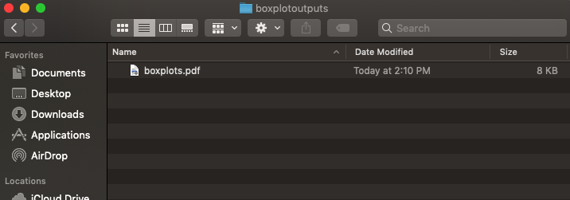

## generate one-way or two-way hierarchical clustering analysis

The `get_hca` function is to perform two-way hierarchical clustering analysis and generates a heatmap showing the clustering results. The input intensity matrix could be transformed or non-transformed intensities. Sample labels in the class labels file should be in the same order as the intensity matrix or feature table.

### generate one-way hierarchical clustering heatmap

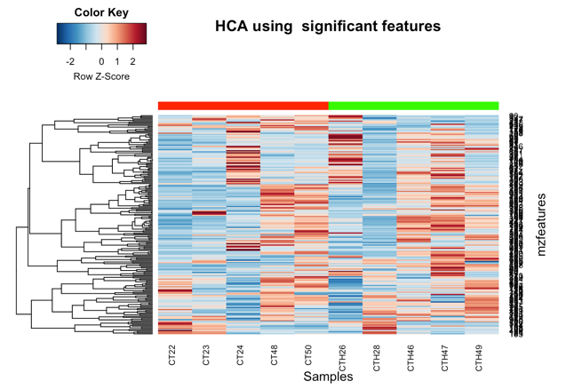

```r
#set up your working directory
setwd("~/Desktop/xmsPANDA_current20190302/myfiles")
#read the feature table
feat=read.table('expanda_feattable.txt',sep='\t',header=TRUE,stringsAsFactors = FALSE,check.names = FALSE)
#read the classlabel file
clabel=read.table('classlabels.txt',sep='\t',header=TRUE,stringsAsFactors = FALSE,check.names = FALSE)
get_hca(X = feat[1:200,], Y = clabel,
             feature_table_file=NA, parentoutput_dir='./hcaoutputs', class_labels_file=NA,
             heatmap.col.opt = "RdBu",
             cor.method = "spearman",is.data.znorm = FALSE, analysismode = "classification",
             sample.col.opt = "rainbow", plots.width = 2000,
            plots.height = 2000, plots.res = 300, alphacol = 0.3,hca_type="one-way")
```

### generate two-way hierarchical clustering heatmap

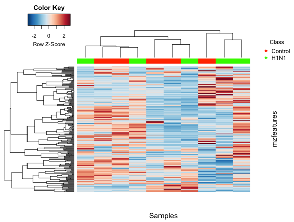

```r
#set up your working directory
setwd("~/Desktop/xmsPANDA_current20190302/myfiles")
#read the feature table
feat=read.table('expanda_feattable.txt',sep='\t',header=TRUE,stringsAsFactors = FALSE,check.names = FALSE)
#read the classlabel file
clabel=read.table('classlabels.txt',sep='\t',header=TRUE,stringsAsFactors = FALSE,check.names = FALSE)
get_hca(X = feat[1:200,], Y = clabel,
             feature_table_file=NA, parentoutput_dir='./hcaoutputs', class_labels_file=NA,
             heatmap.col.opt = "RdBu",
             cor.method = "spearman",is.data.znorm = FALSE, analysismode = "classification",
             sample.col.opt = "rainbow", plots.width = 2000,
            plots.height = 2000, plots.res = 300, alphacol = 0.3,hca_type="two-way")
```

In the case above, I generated one-way or two-way hierarchical clustering heatmap for the top 200 features in the feature table. Except for generating the heatmap, this function also generates the folder called ‘hcaoutputs’ in your current working directory. Under this folder, there is one subfolder called ‘Table’. There are three files under this subfolder. These files can tell you how the samples were clustered and also let you know that the order of the samples in the heatmap.

[figure not shown]

## generate PCA score distribution plots

The `get_pcascoredistplots` function is to perform principal component analysis and generates PCA score distribution plots.

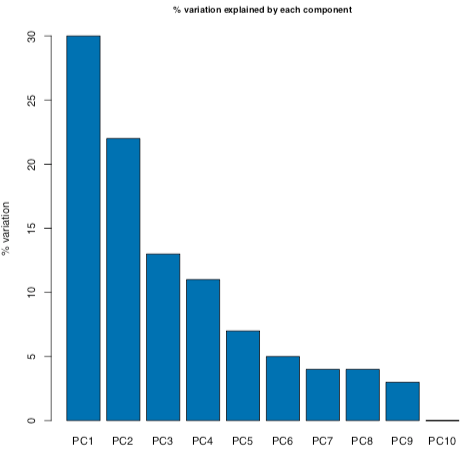

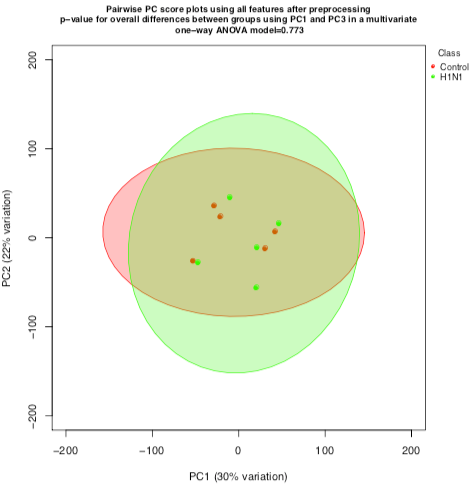

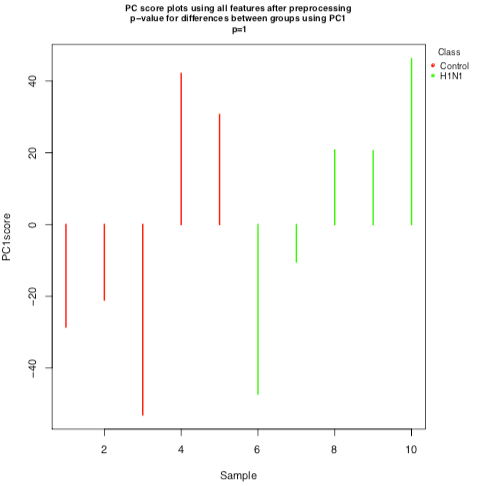

```r
#set up your working directory
setwd("~/Desktop/xmsPANDA_current20190302/myfiles")
#read the feature table
feat=read.table('expanda_feattable.txt',sep='\t',header=TRUE,stringsAsFactors = FALSE,check.names = FALSE)
#read the classlabel file
clabel=read.table('classlabels.txt',sep='\t',header=TRUE,stringsAsFactors = FALSE,check.names = FALSE)
pdf('pca_plots.pdf')
res <- get_pcascoredistplots(X = feat, Y = clabel,
                      feature_table_file=NA, parentoutput_dir='./PCAoutputs',
                      class_labels_file=NA, sample.col.opt = "rainbow", plots.width = 2000,
                      plots.height = 2000, plots.res = 300, alphacol = 0.3, col_vec=NA,
                      pairedanalysis = FALSE, pca.cex.val = 3, legendlocation = "topright",
                      pca.ellipse = TRUE, ellipse.conf.level = 0.5, filename = "all")
dev.off()
```

In the case above, I performed principal component analysis and generates a series of PCA plots. After running the above code, you will see a pdf file generated under your current working directory. All the figures were in this file. It also generate a folder called ‘PCAoutputs’ and its subfolder ‘Tables’. All the PCA scores and loading information is under the ‘Tables’ folder.

[figure not shown]

## generate ROC curves

The `get_roc` function is to generate Receiver Operating Characteristic(ROC) curves using SVM and Logistic Regression as classifiers.

```r
#set up your working directory
setwd("~/Desktop/xmsPANDA_current20190302/myfiles")
#read the feature table
feat=read.table('expanda_feattable.txt',sep='\t',header=TRUE,stringsAsFactors = FALSE,check.names = FALSE)
#read the classlabel file
clabel=read.table('classlabels.txt',sep='\t',header=TRUE,stringsAsFactors = FALSE,check.names = FALSE)

get_roc(dataA=feat[sample(dim(feat)[1],size = 200,replace = FALSE),], classlabels=clabel$Class, classifier = "svm", kname = "radial", rocfeatlist = seq(2, 10, 1), rocfeatincrement = TRUE,
        testset = NA, testclasslabels = NA, mainlabel = NA)
```

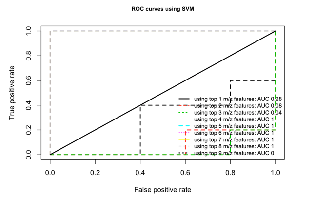

In the case above, I randomly selected 200 features from feature table ans assumed them as differentially expressed features. In the real case, you should select the significant features based on p-value or VIP.

## Perform Pearson or Spearman correlation based network analysis

The `metabnet` function is a function for correlation (complete or partial) based metabolome-wide network analysis. This function was published in [Frontiers in Bioengineering and Biotechnology](https://www.frontiersin.org/articles/10.3389/fbioe.2015.00087/full). In the example below, we used example data from [metabnet resource](https://sourceforge.net/projects/metabnet/files/Tutorial_files/) on sourceforge website.

```r
#set up your working directory
setwd("~/Desktop/xmsPANDA_current20190302/myfiles")
#get the full path of the example feature table
exampledata <- paste(getwd(),'input_feature_table.txt',sep='/')
#get the full path of the metabolite target list
targetlist <- paste(getwd(),'target_list.txt',sep='/')
#set up your output folder
output <- paste(getwd(),'metabnetoutput',sep='/')

res <- metabnet(feature_table_file=exampledata,target.metab.file=targetlist,sig.metab.file=NA,
                class_labels_file=NA,parentoutput_dir=output,num_replicates=1,
                cor.method="spearman",abs.cor.thresh=0.3,cor.fdrthresh=0.05,target.mzmatch.diff=10,
                target.rtmatch.diff=NA,max.cor.num=100,feat.filt.thresh=NA,summarize.replicates=TRUE,
                summary.method="mean",all.missing.thresh=0.5,group.missing.thresh=0.7,log2transform=TRUE,
                medcenter=FALSE,znormtransform=FALSE,quantile_norm=TRUE,lowess_norm=FALSE,madscaling=FALSE,
                missing.val=0,networktype="complete",samplermindex=NA,rep.max.missing.thresh=0.3,
                summary.na.replacement="zeros",net_node_colors = c("pink", "skyblue"),net_legend = FALSE)
```

In the case above, I used the example feature table which contains 50 samples (technical replicates were summarized already) and 5407 metabolic features, and the example target list which contains 288 target metabolites to run `metabnet` with Spearman correlation method, 0.3 as absolute correlation threshod and 0.05 as FDR threshod. First of all, the program tried to summarize the technical replicates if you haven’t pre-processed them yet. Then it filtered the features which doesn’t satisfy the filtering criteria the users provided. Here I used overall 50% signal criteria and group-wise 70% signal criteria for filtering. After that, the program tried to match the metabolites in the target list with the metabolic features in the feature table by using 10ppm. In this case, we found 13 unique matched metabolites (Please see the figure below). Then the program would generate a correlation network between the matched target metabolties and the other metabolic features.

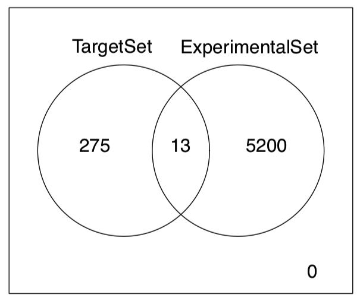

After the program was finished, the output folder ‘metabnetoutput’ was gerenated and there were two sub folders ‘Stage1’ and ‘Stage4’ under it. The ‘Stage1’ folder contains the summarized data information and the ‘stage4’ folder contains all correlation network outputs (Please see the figures below). All the file names indicate what the files contain.

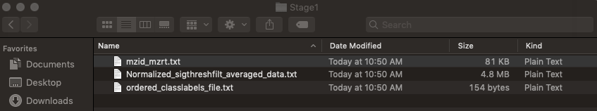

[figure not shown]